# Chapter3notes

Nicole E Soltis

February 19, 2016

## Example 3.1

```r
PrPV <- 0.95
PrPM <- 0.01
PrV <- 0.001
PrP <- PrPV*PrV + PrPM*(1-PrV)
( PrVP <- PrPV*PrV / PrP )
```

```
## [1] 0.08683729
```

## 3.2

```r
p_grid <- seq( from=0 , to=1 , length.out=1000 )
prior <- rep( 1 , 1000 )
likelihood <- dbinom( 6 , size=9 , prob=p_grid )
posterior <- likelihood * prior
posterior <- posterior / sum(posterior)
```

## 3.3 random sampling with replacement from the vector p_grid

```r
samples <- sample( p_grid , prob=posterior , size=1e4 , replace=TRUE )
```

if not including prob=posterior, will sample randomly

## 3.4

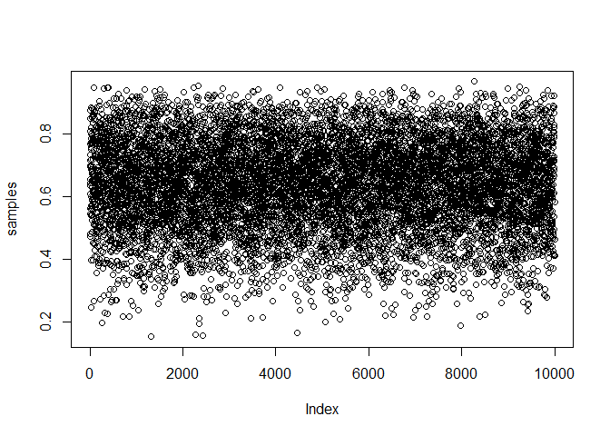

```r
plot(samples)
```

## 3.5

```r
library(rethinking)
dens(samples)
```

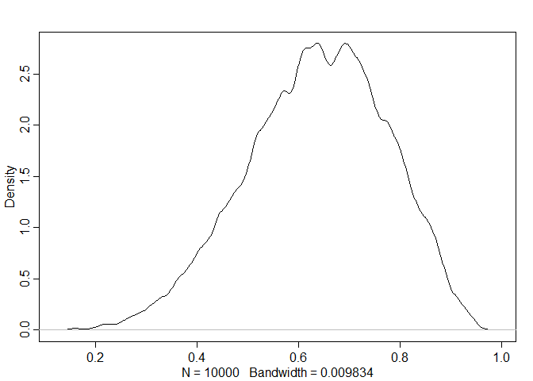

## 3.6

add up posterior probability where p < 0.5

```r
sum( posterior[ p_grid < 0.5 ] )
```

```
## [1] 0.1718746
```

## 3.7

```r
sum( samples < 0.5 ) / 1e4
```

```
## [1] 0.1665
```

## 3.8

```r
sum( samples > 0.5 & samples < 0.75 ) / 1e4
```

```
## [1] 0.6141
```

## 3.9

```r
quantile( samples , 0.8 )
```

```
##       80%
## 0.7597598
```

80% of the data is below this cutoff

## 3.10

```r
quantile( samples , c( 0.1 , 0.9 ) )
```

```
##       10%       90%
## 0.4494494 0.8118118
```

## 3.11

```r
p_grid <- seq( from=0 , to=1 , length.out=1000 )
prior <- rep(1,1000)
likelihood <- dbinom( 3 , size=3 , prob=p_grid )
posterior <- likelihood * prior
posterior <- posterior / sum(posterior)
samples <- sample( p_grid , size=1e4 , replace=TRUE , prob=posterior )
```

## 3.12

```r
PI( samples , prob=0.5 )
```

```
##       25%       75%
## 0.7064565 0.9309309
```

percentile interval

## 3.13

```r
HPDI( samples , prob=0.5 )
```

```
##      |0.5      0.5|
## 0.8408408 1.0000000
```

highest posterior density interval

narrowest interval

if data is normal or perfectly symmetrical, HPDI is equal to PI

more different if data is skewed

## 3.14

```r
p_grid[ which.max(posterior) ]
```

```
## [1] 1
```

## 3.15

```r
chainmode( samples , adj=0.01 )
```

```
## [1] 0.9857175
```

## 3.16

```r
mean( samples )
```

```
## [1] 0.7994526
```

```r
median( samples )
```

```
## [1] 0.8408408
```

## 3.17

```r
sum( posterior*abs( 0.5 - p_grid ) )
```

```
## [1] 0.3128752
```

## 3.18

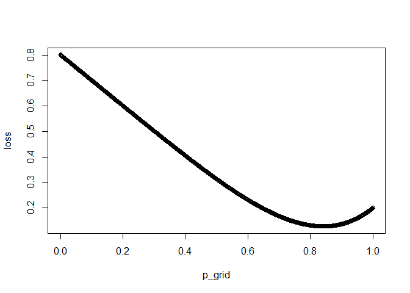

```r
#d is set to one value of p_grid vector at a time
#and for each value of d, calculates a new vector of difference between d and ALL of p_grid
#figuring out loss for EVERY POSSIBLE decision, d
loss <- sapply( p_grid , function(d) sum( posterior*abs( d - p_grid ) ) )
plot(p_grid,loss)
```

```r
which.min(loss)
```

```
## [1] 841
```

```r
p_grid[which.min(loss)]
```

```
## [1] 0.8408408
```

sapply: take each item in (vector or list), apply function to it

similar to pulling a function down a column in excel

```r
square_a_number <- function(x) x*x
sapply(p_grid, square_a_number)
```

[output not shown]

[output cut: 185 more lines]

```r
#quicker version
sapply(p_grid, function(x) x*x)
```

[output not shown]

[output cut: 185 more lines]

## 3.19

```r
p_grid[ which.min(loss) ]
```

```
## [1] 0.8408408
```

## 3.20

```r
dbinom( 0:2 , size=2 , prob=0.7 )
```

```
## [1] 0.09 0.42 0.49
```

## 3.21

Dummy data observation of seeing W in 2 tosses of globe

```r
rbinom( 1 , size=2 , prob=0.7 )
```

```
## [1] 1
```

## 3.22

Run 10 simulations

```r
set.seed(100)
rbinom( 10 , size=2 , prob=0.7 )
```

```
##  [1] 2 2 1 2 2 2 1 2 1 2
```

## 3.23

In 100k observations, each value occurs in proportion to its likelihood

```r
dummy_w <- rbinom( 1e5 , size=2 , prob=0.7 )
table(dummy_w)/1e5
```

```
## dummy_w
##       0       1       2
## 0.09016 0.41703 0.49281
```

## 3.24

now with a 9-toss sample size

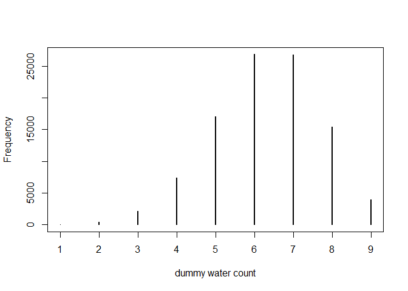

```r
library(rethinking)
dummy_w <- rbinom( 1e5 , size=9 , prob=0.7 )
simplehist( dummy_w , xlab="dummy water count" )
```

## 3.25

simulate 10k predicted observations for 9 tosses

[figure not shown]

```r
w <- rbinom( 1e4 , size=9 , prob=0.6 )
library(rethinking)
simplehist(w)
```

next, propagate parameter uncertainty

replace prob with samples from the posterior

## 3.26

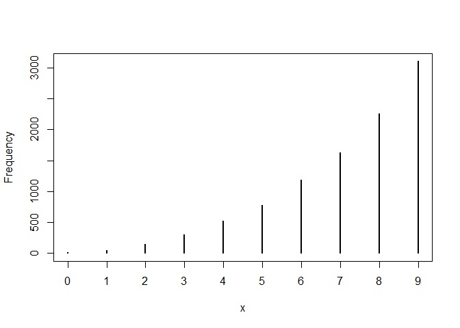

```r
#from 3.11
p_grid <- seq( from=0 , to=1 , length.out=1000 )
prior <- rep(1,1000)
likelihood <- dbinom( 3 , size=3 , prob=p_grid )
posterior <- likelihood * prior
posterior <- posterior / sum(posterior)
samples <- sample( p_grid , size=1e4 , replace=TRUE , prob=posterior )
w <- rbinom( 1e4 , size=9 , prob=samples )
library(rethinking)
simplehist(w)
```

## 3.28

```r
library(rethinking)
data(homeworkch3)

sum(birth1) + sum(birth2)
```

```
## [1] 111
```

## class notes

what’s the point of all this?

observations

prior (some assumptions and/ or previous observations)

likelihood

posterior (distribution of parameter estimates)

sampling

describe distribution of a population

iteratively incorporate information from modeling to improve your estimation/ modeling

estimate structure of your population/ data set

incorporate previous knowledge

understand whether your model works

estimate certainty in your model/ estimation

1. develop a model that fits our data (to the extent possible)
2. use the model to estimate parameters (or principles)
3. make predictions and compare to other situations/ datasets. Describe data in ways that are not purely numeric.